# Восстановление золота из руды

Подготовьте прототип модели машинного обучения для «Цифры». Компания разрабатывает решения для эффективной работы промышленных предприятий.

Модель должна предсказать коэффициент восстановления золота из золотосодержащей руды. Используйте данные с параметрами добычи и очистки.

Модель поможет оптимизировать производство, чтобы не запускать предприятие с убыточными характеристиками.

Вам нужно:

1. Подготовить данные;
2. Провести исследовательский анализ данных;
3. Построить и обучить модель.

Чтобы выполнить проект, обращайтесь к библиотекам *pandas*, *matplotlib* и *sklearn.* Вам поможет их документация.

*import необходимых библиотек*

```python
import numpy as np
import pandas as pd
import matplotlib as mpl
import matplotlib.pyplot as plt
import scipy.stats as stats

from sklearn.model_selection import train_test_split
from sklearn.linear_model import LinearRegression
from sklearn.tree import DecisionTreeRegressor
from sklearn.linear_model import LogisticRegression

from sklearn.metrics import mean_squared_error
from sklearn.metrics import r2_score
from sklearn.metrics import make_scorer
from sklearn.model_selection import cross_val_score

from sklearn.metrics import confusion_matrix
from sklearn.metrics import recall_score
from sklearn.metrics import precision_score
from sklearn.metrics import f1_score
from sklearn.metrics import roc_auc_score, roc_curve

from sklearn.ensemble import RandomForestClassifier
from sklearn.ensemble import RandomForestRegressor
from sklearn.model_selection import GridSearchCV

from sklearn.preprocessing import StandardScaler
```

```python
import warnings
warnings.filterwarnings('ignore')
```

## Подготовка данных

### Откройте файлы и изучите их.

```python
gold_recovery_train = pd.read_csv('/datasets/gold_recovery_train_new.csv')
gold_recovery_test = pd.read_csv('/datasets/gold_recovery_test_new.csv')
gold_recovery_full = pd.read_csv('/datasets/gold_recovery_full_new.csv')
```

*Первый датасет - train*

```python
gold_recovery_train.head(5)
```

|  | date | final.output.concentrate_ag | final.output.concentrate_pb | final.output.concentrate_sol | final.output.concentrate_au | final.output.recovery | final.output.tail_ag | final.output.tail_pb | final.output.tail_sol | final.output.tail_au | ... | secondary_cleaner.state.floatbank4_a_air | secondary_cleaner.state.floatbank4_a_level | secondary_cleaner.state.floatbank4_b_air | secondary_cleaner.state.floatbank4_b_level | secondary_cleaner.state.floatbank5_a_air | secondary_cleaner.state.floatbank5_a_level | secondary_cleaner.state.floatbank5_b_air | secondary_cleaner.state.floatbank5_b_level | secondary_cleaner.state.floatbank6_a_air | secondary_cleaner.state.floatbank6_a_level |
| --- | --- | --- | --- | --- | --- | --- | --- | --- | --- | --- | --- | --- | --- | --- | --- | --- | --- | --- | --- | --- | --- |
| 0 | 2016-01-15 00:00:00 | 6.055403 | 9.889648 | 5.507324 | 42.192020 | 70.541216 | 10.411962 | 0.895447 | 16.904297 | 2.143149 | ... | 14.016835 | -502.488007 | 12.099931 | -504.715942 | 9.925633 | -498.310211 | 8.079666 | -500.470978 | 14.151341 | -605.841980 |
| 1 | 2016-01-15 01:00:00 | 6.029369 | 9.968944 | 5.257781 | 42.701629 | 69.266198 | 10.462676 | 0.927452 | 16.634514 | 2.224930 | ... | 13.992281 | -505.503262 | 11.950531 | -501.331529 | 10.039245 | -500.169983 | 7.984757 | -500.582168 | 13.998353 | -599.787184 |
| 2 | 2016-01-15 02:00:00 | 6.055926 | 10.213995 | 5.383759 | 42.657501 | 68.116445 | 10.507046 | 0.953716 | 16.208849 | 2.257889 | ... | 14.015015 | -502.520901 | 11.912783 | -501.133383 | 10.070913 | -500.129135 | 8.013877 | -500.517572 | 14.028663 | -601.427363 |
| 3 | 2016-01-15 03:00:00 | 6.047977 | 9.977019 | 4.858634 | 42.689819 | 68.347543 | 10.422762 | 0.883763 | 16.532835 | 2.146849 | ... | 14.036510 | -500.857308 | 11.999550 | -501.193686 | 9.970366 | -499.201640 | 7.977324 | -500.255908 | 14.005551 | -599.996129 |
| 4 | 2016-01-15 04:00:00 | 6.148599 | 10.142511 | 4.939416 | 42.774141 | 66.927016 | 10.360302 | 0.792826 | 16.525686 | 2.055292 | ... | 14.027298 | -499.838632 | 11.953070 | -501.053894 | 9.925709 | -501.686727 | 7.894242 | -500.356035 | 13.996647 | -601.496691 |

5 rows × 87 columns

```python
gold_recovery_train.info()
```

```
<class 'pandas.core.frame.DataFrame'>
RangeIndex: 14149 entries, 0 to 14148
Data columns (total 87 columns):
date                                                  14149 non-null object
final.output.concentrate_ag                           14148 non-null float64
final.output.concentrate_pb                           14148 non-null float64
final.output.concentrate_sol                          13938 non-null float64
final.output.concentrate_au                           14149 non-null float64
final.output.recovery                                 14149 non-null float64
final.output.tail_ag                                  14149 non-null float64
final.output.tail_pb                                  14049 non-null float64
final.output.tail_sol                                 14144 non-null float64
final.output.tail_au                                  14149 non-null float64
primary_cleaner.input.sulfate                         14129 non-null float64
primary_cleaner.input.depressant                      14117 non-null float64
primary_cleaner.input.feed_size                       14149 non-null float64
primary_cleaner.input.xanthate                        14049 non-null float64
primary_cleaner.output.concentrate_ag                 14149 non-null float64
primary_cleaner.output.concentrate_pb                 14063 non-null float64
primary_cleaner.output.concentrate_sol                13863 non-null float64
primary_cleaner.output.concentrate_au                 14149 non-null float64
primary_cleaner.output.tail_ag                        14148 non-null float64
primary_cleaner.output.tail_pb                        14134 non-null float64
primary_cleaner.output.tail_sol                       14103 non-null float64
primary_cleaner.output.tail_au                        14149 non-null float64
primary_cleaner.state.floatbank8_a_air                14145 non-null float64
primary_cleaner.state.floatbank8_a_level              14148 non-null float64
primary_cleaner.state.floatbank8_b_air                14145 non-null float64
primary_cleaner.state.floatbank8_b_level              14148 non-null float64
primary_cleaner.state.floatbank8_c_air                14147 non-null float64
primary_cleaner.state.floatbank8_c_level              14148 non-null float64
primary_cleaner.state.floatbank8_d_air                14146 non-null float64
primary_cleaner.state.floatbank8_d_level              14148 non-null float64
rougher.calculation.sulfate_to_au_concentrate         14148 non-null float64
rougher.calculation.floatbank10_sulfate_to_au_feed    14148 non-null float64
rougher.calculation.floatbank11_sulfate_to_au_feed    14148 non-null float64
rougher.calculation.au_pb_ratio                       14149 non-null float64
rougher.input.feed_ag                                 14149 non-null float64
rougher.input.feed_pb                                 14049 non-null float64
rougher.input.feed_rate                               14141 non-null float64
```

[output cut: 37 more lines]

```
secondary_cleaner.state.floatbank3_a_level            14148 non-null float64
secondary_cleaner.state.floatbank3_b_air              14148 non-null float64
secondary_cleaner.state.floatbank3_b_level            14148 non-null float64
secondary_cleaner.state.floatbank4_a_air              14143 non-null float64
secondary_cleaner.state.floatbank4_a_level            14148 non-null float64
secondary_cleaner.state.floatbank4_b_air              14148 non-null float64
secondary_cleaner.state.floatbank4_b_level            14148 non-null float64
secondary_cleaner.state.floatbank5_a_air              14148 non-null float64
secondary_cleaner.state.floatbank5_a_level            14148 non-null float64
secondary_cleaner.state.floatbank5_b_air              14148 non-null float64
secondary_cleaner.state.floatbank5_b_level            14148 non-null float64
secondary_cleaner.state.floatbank6_a_air              14147 non-null float64
secondary_cleaner.state.floatbank6_a_level            14148 non-null float64
dtypes: float64(86), object(1)
memory usage: 9.4+ MB
```

*Второй датасет - test*

```python
gold_recovery_test.head(5)
```

|  | date | primary_cleaner.input.sulfate | primary_cleaner.input.depressant | primary_cleaner.input.feed_size | primary_cleaner.input.xanthate | primary_cleaner.state.floatbank8_a_air | primary_cleaner.state.floatbank8_a_level | primary_cleaner.state.floatbank8_b_air | primary_cleaner.state.floatbank8_b_level | primary_cleaner.state.floatbank8_c_air | ... | secondary_cleaner.state.floatbank4_a_air | secondary_cleaner.state.floatbank4_a_level | secondary_cleaner.state.floatbank4_b_air | secondary_cleaner.state.floatbank4_b_level | secondary_cleaner.state.floatbank5_a_air | secondary_cleaner.state.floatbank5_a_level | secondary_cleaner.state.floatbank5_b_air | secondary_cleaner.state.floatbank5_b_level | secondary_cleaner.state.floatbank6_a_air | secondary_cleaner.state.floatbank6_a_level |
| --- | --- | --- | --- | --- | --- | --- | --- | --- | --- | --- | --- | --- | --- | --- | --- | --- | --- | --- | --- | --- | --- |
| 0 | 2016-09-01 00:59:59 | 210.800909 | 14.993118 | 8.080000 | 1.005021 | 1398.981301 | -500.225577 | 1399.144926 | -499.919735 | 1400.102998 | ... | 12.023554 | -497.795834 | 8.016656 | -501.289139 | 7.946562 | -432.317850 | 4.872511 | -500.037437 | 26.705889 | -499.709414 |
| 1 | 2016-09-01 01:59:59 | 215.392455 | 14.987471 | 8.080000 | 0.990469 | 1398.777912 | -500.057435 | 1398.055362 | -499.778182 | 1396.151033 | ... | 12.058140 | -498.695773 | 8.130979 | -499.634209 | 7.958270 | -525.839648 | 4.878850 | -500.162375 | 25.019940 | -499.819438 |
| 2 | 2016-09-01 02:59:59 | 215.259946 | 12.884934 | 7.786667 | 0.996043 | 1398.493666 | -500.868360 | 1398.860436 | -499.764529 | 1398.075709 | ... | 11.962366 | -498.767484 | 8.096893 | -500.827423 | 8.071056 | -500.801673 | 4.905125 | -499.828510 | 24.994862 | -500.622559 |
| 3 | 2016-09-01 03:59:59 | 215.336236 | 12.006805 | 7.640000 | 0.863514 | 1399.618111 | -498.863574 | 1397.440120 | -499.211024 | 1400.129303 | ... | 12.033091 | -498.350935 | 8.074946 | -499.474407 | 7.897085 | -500.868509 | 4.931400 | -499.963623 | 24.948919 | -498.709987 |
| 4 | 2016-09-01 04:59:59 | 199.099327 | 10.682530 | 7.530000 | 0.805575 | 1401.268123 | -500.808305 | 1398.128818 | -499.504543 | 1402.172226 | ... | 12.025367 | -500.786497 | 8.054678 | -500.397500 | 8.107890 | -509.526725 | 4.957674 | -500.360026 | 25.003331 | -500.856333 |

5 rows × 53 columns

```python
gold_recovery_test.info()
```

```
<class 'pandas.core.frame.DataFrame'>
RangeIndex: 5290 entries, 0 to 5289
Data columns (total 53 columns):
date                                          5290 non-null object
primary_cleaner.input.sulfate                 5286 non-null float64
primary_cleaner.input.depressant              5285 non-null float64
primary_cleaner.input.feed_size               5290 non-null float64
primary_cleaner.input.xanthate                5286 non-null float64
primary_cleaner.state.floatbank8_a_air        5290 non-null float64
primary_cleaner.state.floatbank8_a_level      5290 non-null float64
primary_cleaner.state.floatbank8_b_air        5290 non-null float64
primary_cleaner.state.floatbank8_b_level      5290 non-null float64
primary_cleaner.state.floatbank8_c_air        5290 non-null float64
primary_cleaner.state.floatbank8_c_level      5290 non-null float64
primary_cleaner.state.floatbank8_d_air        5290 non-null float64
primary_cleaner.state.floatbank8_d_level      5290 non-null float64
rougher.input.feed_ag                         5290 non-null float64
rougher.input.feed_pb                         5290 non-null float64
rougher.input.feed_rate                       5287 non-null float64
rougher.input.feed_size                       5289 non-null float64
rougher.input.feed_sol                        5269 non-null float64
rougher.input.feed_au                         5290 non-null float64
rougher.input.floatbank10_sulfate             5285 non-null float64
rougher.input.floatbank10_xanthate            5290 non-null float64
rougher.input.floatbank11_sulfate             5282 non-null float64
rougher.input.floatbank11_xanthate            5265 non-null float64
rougher.state.floatbank10_a_air               5290 non-null float64
rougher.state.floatbank10_a_level             5290 non-null float64
rougher.state.floatbank10_b_air               5290 non-null float64
rougher.state.floatbank10_b_level             5290 non-null float64
rougher.state.floatbank10_c_air               5290 non-null float64
rougher.state.floatbank10_c_level             5290 non-null float64
rougher.state.floatbank10_d_air               5290 non-null float64
rougher.state.floatbank10_d_level             5290 non-null float64
rougher.state.floatbank10_e_air               5290 non-null float64
rougher.state.floatbank10_e_level             5290 non-null float64
rougher.state.floatbank10_f_air               5290 non-null float64
rougher.state.floatbank10_f_level             5290 non-null float64
secondary_cleaner.state.floatbank2_a_air      5287 non-null float64
secondary_cleaner.state.floatbank2_a_level    5290 non-null float64
secondary_cleaner.state.floatbank2_b_air      5288 non-null float64
secondary_cleaner.state.floatbank2_b_level    5290 non-null float64
secondary_cleaner.state.floatbank3_a_air      5281 non-null float64
secondary_cleaner.state.floatbank3_a_level    5290 non-null float64
secondary_cleaner.state.floatbank3_b_air      5290 non-null float64
secondary_cleaner.state.floatbank3_b_level    5290 non-null float64
secondary_cleaner.state.floatbank4_a_air      5290 non-null float64
secondary_cleaner.state.floatbank4_a_level    5290 non-null float64
secondary_cleaner.state.floatbank4_b_air      5290 non-null float64
secondary_cleaner.state.floatbank4_b_level    5290 non-null float64
secondary_cleaner.state.floatbank5_a_air      5290 non-null float64
secondary_cleaner.state.floatbank5_a_level    5290 non-null float64
secondary_cleaner.state.floatbank5_b_air      5290 non-null float64
secondary_cleaner.state.floatbank5_b_level    5290 non-null float64
secondary_cleaner.state.floatbank6_a_air      5290 non-null float64
secondary_cleaner.state.floatbank6_a_level    5290 non-null float64
dtypes: float64(52), object(1)
memory usage: 2.1+ MB
```

*Третий датасет - full*

```python
gold_recovery_full.head(5)
```

|  | date | final.output.concentrate_ag | final.output.concentrate_pb | final.output.concentrate_sol | final.output.concentrate_au | final.output.recovery | final.output.tail_ag | final.output.tail_pb | final.output.tail_sol | final.output.tail_au | ... | secondary_cleaner.state.floatbank4_a_air | secondary_cleaner.state.floatbank4_a_level | secondary_cleaner.state.floatbank4_b_air | secondary_cleaner.state.floatbank4_b_level | secondary_cleaner.state.floatbank5_a_air | secondary_cleaner.state.floatbank5_a_level | secondary_cleaner.state.floatbank5_b_air | secondary_cleaner.state.floatbank5_b_level | secondary_cleaner.state.floatbank6_a_air | secondary_cleaner.state.floatbank6_a_level |
| --- | --- | --- | --- | --- | --- | --- | --- | --- | --- | --- | --- | --- | --- | --- | --- | --- | --- | --- | --- | --- | --- |
| 0 | 2016-01-15 00:00:00 | 6.055403 | 9.889648 | 5.507324 | 42.192020 | 70.541216 | 10.411962 | 0.895447 | 16.904297 | 2.143149 | ... | 14.016835 | -502.488007 | 12.099931 | -504.715942 | 9.925633 | -498.310211 | 8.079666 | -500.470978 | 14.151341 | -605.841980 |
| 1 | 2016-01-15 01:00:00 | 6.029369 | 9.968944 | 5.257781 | 42.701629 | 69.266198 | 10.462676 | 0.927452 | 16.634514 | 2.224930 | ... | 13.992281 | -505.503262 | 11.950531 | -501.331529 | 10.039245 | -500.169983 | 7.984757 | -500.582168 | 13.998353 | -599.787184 |
| 2 | 2016-01-15 02:00:00 | 6.055926 | 10.213995 | 5.383759 | 42.657501 | 68.116445 | 10.507046 | 0.953716 | 16.208849 | 2.257889 | ... | 14.015015 | -502.520901 | 11.912783 | -501.133383 | 10.070913 | -500.129135 | 8.013877 | -500.517572 | 14.028663 | -601.427363 |
| 3 | 2016-01-15 03:00:00 | 6.047977 | 9.977019 | 4.858634 | 42.689819 | 68.347543 | 10.422762 | 0.883763 | 16.532835 | 2.146849 | ... | 14.036510 | -500.857308 | 11.999550 | -501.193686 | 9.970366 | -499.201640 | 7.977324 | -500.255908 | 14.005551 | -599.996129 |
| 4 | 2016-01-15 04:00:00 | 6.148599 | 10.142511 | 4.939416 | 42.774141 | 66.927016 | 10.360302 | 0.792826 | 16.525686 | 2.055292 | ... | 14.027298 | -499.838632 | 11.953070 | -501.053894 | 9.925709 | -501.686727 | 7.894242 | -500.356035 | 13.996647 | -601.496691 |

5 rows × 87 columns

```python
gold_recovery_full.info()
```

```
<class 'pandas.core.frame.DataFrame'>
RangeIndex: 19439 entries, 0 to 19438
Data columns (total 87 columns):
date                                                  19439 non-null object
final.output.concentrate_ag                           19438 non-null float64
final.output.concentrate_pb                           19438 non-null float64
final.output.concentrate_sol                          19228 non-null float64
final.output.concentrate_au                           19439 non-null float64
final.output.recovery                                 19439 non-null float64
final.output.tail_ag                                  19438 non-null float64
final.output.tail_pb                                  19338 non-null float64
final.output.tail_sol                                 19433 non-null float64
final.output.tail_au                                  19439 non-null float64
primary_cleaner.input.sulfate                         19415 non-null float64
primary_cleaner.input.depressant                      19402 non-null float64
primary_cleaner.input.feed_size                       19439 non-null float64
primary_cleaner.input.xanthate                        19335 non-null float64
primary_cleaner.output.concentrate_ag                 19439 non-null float64
primary_cleaner.output.concentrate_pb                 19323 non-null float64
primary_cleaner.output.concentrate_sol                19069 non-null float64
primary_cleaner.output.concentrate_au                 19439 non-null float64
primary_cleaner.output.tail_ag                        19435 non-null float64
primary_cleaner.output.tail_pb                        19418 non-null float64
primary_cleaner.output.tail_sol                       19377 non-null float64
primary_cleaner.output.tail_au                        19439 non-null float64
primary_cleaner.state.floatbank8_a_air                19435 non-null float64
primary_cleaner.state.floatbank8_a_level              19438 non-null float64
primary_cleaner.state.floatbank8_b_air                19435 non-null float64
primary_cleaner.state.floatbank8_b_level              19438 non-null float64
primary_cleaner.state.floatbank8_c_air                19437 non-null float64
primary_cleaner.state.floatbank8_c_level              19438 non-null float64
primary_cleaner.state.floatbank8_d_air                19436 non-null float64
primary_cleaner.state.floatbank8_d_level              19438 non-null float64
rougher.calculation.sulfate_to_au_concentrate         19437 non-null float64
rougher.calculation.floatbank10_sulfate_to_au_feed    19437 non-null float64
rougher.calculation.floatbank11_sulfate_to_au_feed    19437 non-null float64
rougher.calculation.au_pb_ratio                       19439 non-null float64
rougher.input.feed_ag                                 19439 non-null float64
rougher.input.feed_pb                                 19339 non-null float64
rougher.input.feed_rate                               19428 non-null float64
```

[output cut: 37 more lines]

```
secondary_cleaner.state.floatbank3_a_level            19438 non-null float64
secondary_cleaner.state.floatbank3_b_air              19438 non-null float64
secondary_cleaner.state.floatbank3_b_level            19438 non-null float64
secondary_cleaner.state.floatbank4_a_air              19433 non-null float64
secondary_cleaner.state.floatbank4_a_level            19438 non-null float64
secondary_cleaner.state.floatbank4_b_air              19438 non-null float64
secondary_cleaner.state.floatbank4_b_level            19438 non-null float64
secondary_cleaner.state.floatbank5_a_air              19438 non-null float64
secondary_cleaner.state.floatbank5_a_level            19438 non-null float64
secondary_cleaner.state.floatbank5_b_air              19438 non-null float64
secondary_cleaner.state.floatbank5_b_level            19438 non-null float64
secondary_cleaner.state.floatbank6_a_air              19437 non-null float64
secondary_cleaner.state.floatbank6_a_level            19438 non-null float64
dtypes: float64(86), object(1)
memory usage: 12.9+ MB
```

### Проверьте, что эффективность обогащения рассчитана правильно. Вычислите её на обучающей выборке для признака rougher.output.recovery. Найдите MAE между вашими расчётами и значением признака. Опишите выводы.

Формула рассчета эффективности обогащения

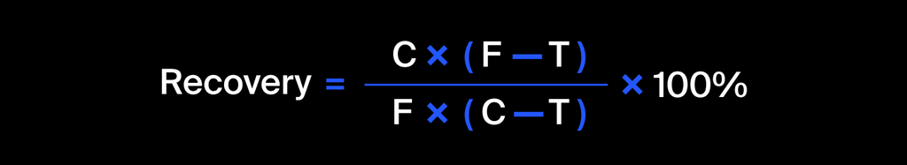

где:

Recovery - эффективность обогащения для признака rougher.output.recovery;

C — доля золота в концентрате после флотации/очистки (rougher.output.concentrate_au);

F — доля золота в сырье/концентрате до флотации/очистки (rougher.input.feed_au);

T — доля золота в отвальных хвостах после флотации/очистки (rougher.output.tail_au).

```python
gold_recovery_train['rougher.output.recovery']
```

```
0        87.107763
1        86.843261
2        86.842308
3        87.226430
4        86.688794
           ...
14144    89.574376
14145    87.724007
14146    88.890579
14147    89.858126
14148    89.514960
Name: rougher.output.recovery, Length: 14149, dtype: float64
```

*Вычисление эффективности*

```python
recovery_calculated = list()

len(gold_recovery_train)
for i in range(len(gold_recovery_train)):
    rec_calc = ((gold_recovery_train['rougher.output.concentrate_au'][i] * (gold_recovery_train['rougher.input.feed_au'][i] - gold_recovery_train['rougher.output.tail_au'][i])) / (gold_recovery_train['rougher.input.feed_au'][i] * (gold_recovery_train['rougher.output.concentrate_au'][i] - gold_recovery_train['rougher.output.tail_au'][i]))) * 100
    recovery_calculated.append(round(rec_calc, 6))
#     print(round(rec_calc, 6))
```

*Вычисление MAE*

```python
error = 0
for i in range(len(recovery_calculated)):
    er = recovery_calculated[i] - gold_recovery_train['rougher.output.recovery'][i]
    error += er
MAE = error / len(recovery_calculated)
print(MAE)
```

```
5.498056301624642e-10
```

*Вывод*

MAE – максимальное неблагоприятное отклонение. В данной ситуации, MAE между нашими расчетами и значением признака примерно равняется 5.5e-10, следовательно, эффективность обогащения рассчитана правильно.

### Проанализируйте признаки, недоступные в тестовой выборке. Что это за параметры? К какому типу относятся?

```python
nedostupnie = list()

for i in range(len(list(gold_recovery_full.columns))):
    if list(gold_recovery_full.columns)[i] not in list(gold_recovery_test.columns):
        nedostupnie.append(list(gold_recovery_full.columns)[i])
        print(list(gold_recovery_full.columns)[i])

# print(nedostupnie)
```

```
final.output.concentrate_ag
final.output.concentrate_pb
final.output.concentrate_sol
final.output.concentrate_au
final.output.recovery
final.output.tail_ag
final.output.tail_pb
final.output.tail_sol
final.output.tail_au
primary_cleaner.output.concentrate_ag
primary_cleaner.output.concentrate_pb
primary_cleaner.output.concentrate_sol
primary_cleaner.output.concentrate_au
primary_cleaner.output.tail_ag
primary_cleaner.output.tail_pb
primary_cleaner.output.tail_sol
primary_cleaner.output.tail_au
rougher.calculation.sulfate_to_au_concentrate
rougher.calculation.floatbank10_sulfate_to_au_feed
rougher.calculation.floatbank11_sulfate_to_au_feed
rougher.calculation.au_pb_ratio
rougher.output.concentrate_ag
rougher.output.concentrate_pb
rougher.output.concentrate_sol
rougher.output.concentrate_au
rougher.output.recovery
rougher.output.tail_ag
rougher.output.tail_pb
rougher.output.tail_sol
rougher.output.tail_au
secondary_cleaner.output.tail_ag
secondary_cleaner.output.tail_pb
secondary_cleaner.output.tail_sol
secondary_cleaner.output.tail_au
```

sorted(list(set(data_train.columns.values) - set(data_test.columns.values))) # проверка # ИЛИ list1 = list(data_train) list2 = list(data_test) result=list(set(list1) ^ set(list2))

### Проведите предобработку данных.

*Исходя из задания:*

Перед нами сырые данные, которые просто выгрузили из хранилища.

Данные индексируются датой и временем получения информации (признак date). Соседние по времени параметры часто похожи. Некоторые параметры недоступны, потому что замеряются и/или рассчитываются значительно позже. Из-за этого в тестовой выборке отсутствуют некоторые признаки, которые могут быть в обучающей. Также в тестовом наборе нет целевых признаков.

*Следовательно:*

1) Сырые данные имеют пропуски и некоторые недоступные параметры, которые замеряются и/или рассчитываются значительно позже. Исходя из этого, некоторые данные, которые заполняются на основе замеров и измерений, а не на основе расчетов, мы заполнить логическими или расчетными эквивалентами не можем.

2) Соседние по времени параметры данные и параметры могут быть похожи, из-за чего мы можем исключить данные с пропусками, так как соответствующие им по дате соседние значения, при дальнейшем построении модели, могут нивелировать их отсутствия и значительно не повлиять на процесс обучения модели и ее конечные результаты.

```python
pd.set_option('display.max_columns', None)
```

```python
gold_recovery_train = gold_recovery_train.loc[gold_recovery_train.notnull().all(axis=1)]
gold_recovery_train = gold_recovery_train.loc[(gold_recovery_train[gold_recovery_train.columns] != 0).any(axis=1)]

gold_recovery_test = gold_recovery_test.loc[gold_recovery_test.notnull().all(axis=1)]
gold_recovery_test = gold_recovery_test.loc[(gold_recovery_test[gold_recovery_test.columns] != 0).any(axis=1)]

gold_recovery_full = gold_recovery_full.loc[gold_recovery_full.notnull().all(axis=1)]
gold_recovery_full = gold_recovery_full.loc[(gold_recovery_full[gold_recovery_full.columns] != 0).any(axis=1)]
```

```python
gold_recovery_train.shape
```

```
(11017, 87)
```

## Анализ данных

### Посмотрите, как меняется концентрация металлов (Au, Ag, Pb) на различных этапах очистки. Опишите выводы.

```python
rougherinput_conc = gold_recovery_full[['rougher.input.feed_ag', 'rougher.input.feed_pb', 'rougher.input.feed_au', 'rougher.input.feed_sol']]
rougherinput_conc['sum'] = rougherinput_conc['rougher.input.feed_ag'] + rougherinput_conc['rougher.input.feed_pb'] + rougherinput_conc['rougher.input.feed_au'] + rougherinput_conc['rougher.input.feed_sol']
display(rougherinput_conc[rougherinput_conc['sum'] <= 1])
```

|  | rougher.input.feed_ag | rougher.input.feed_pb | rougher.input.feed_au | rougher.input.feed_sol | sum |
| --- | --- | --- | --- | --- | --- |
| 16226 | 0.01 | 0.01 | 0.01 | 0.01 | 0.04 |
| 16227 | 0.01 | 0.01 | 0.01 | 0.01 | 0.04 |
| 16228 | 0.01 | 0.01 | 0.01 | 0.01 | 0.04 |
| 16229 | 0.01 | 0.01 | 0.01 | 0.01 | 0.04 |
| 16230 | 0.01 | 0.01 | 0.01 | 0.01 | 0.04 |

```python
rougherinput_conc = rougherinput_conc[rougherinput_conc['sum'] >= 1]
desc1 = rougherinput_conc.describe(include='all').loc['mean']
```

```python
rougheroutput_conc = gold_recovery_full[['rougher.output.concentrate_ag', 'rougher.output.concentrate_pb', 'rougher.output.concentrate_au', 'rougher.output.concentrate_sol']]
rougheroutput_conc['sum'] = rougheroutput_conc['rougher.output.concentrate_ag'] + rougheroutput_conc['rougher.output.concentrate_pb'] + rougheroutput_conc['rougher.output.concentrate_au'] + rougheroutput_conc['rougher.output.concentrate_sol']
display(rougheroutput_conc[rougheroutput_conc['sum'] <= 1])
```

|  | rougher.output.concentrate_ag | rougher.output.concentrate_pb | rougher.output.concentrate_au | rougher.output.concentrate_sol | sum |
| --- | --- | --- | --- | --- | --- |
| 45 | 0.00 | 0.00 | 0.00 | 0.00 | 0.00 |
| 46 | 0.00 | 0.00 | 0.00 | 0.00 | 0.00 |
| 50 | 0.00 | 0.00 | 0.00 | 0.00 | 0.00 |
| 51 | 0.00 | 0.00 | 0.00 | 0.00 | 0.00 |
| 759 | 0.00 | 0.00 | 0.00 | 0.00 | 0.00 |
| ... | ... | ... | ... | ... | ... |
| 16226 | 0.01 | 0.01 | 0.01 | 0.01 | 0.04 |
| 16227 | 0.01 | 0.01 | 0.01 | 0.01 | 0.04 |
| 16228 | 0.01 | 0.01 | 0.01 | 0.01 | 0.04 |
| 16229 | 0.01 | 0.01 | 0.01 | 0.01 | 0.04 |
| 16230 | 0.01 | 0.01 | 0.01 | 0.01 | 0.04 |

306 rows × 5 columns

```python
rougheroutput_conc = rougheroutput_conc[rougheroutput_conc['sum'] >= 1]
desc2 = rougheroutput_conc.describe(include='all').loc['mean']
```

```python
primary_cleaner_conc = gold_recovery_full[['primary_cleaner.output.concentrate_ag', 'primary_cleaner.output.concentrate_pb', 'primary_cleaner.output.concentrate_au', 'primary_cleaner.output.concentrate_sol']]
primary_cleaner_conc['sum'] = primary_cleaner_conc['primary_cleaner.output.concentrate_ag'] + primary_cleaner_conc['primary_cleaner.output.concentrate_pb'] + primary_cleaner_conc['primary_cleaner.output.concentrate_au'] + primary_cleaner_conc['primary_cleaner.output.concentrate_sol']
display(primary_cleaner_conc[primary_cleaner_conc['sum'] <= 1])
```

|  | primary_cleaner.output.concentrate_ag | primary_cleaner.output.concentrate_pb | primary_cleaner.output.concentrate_au | primary_cleaner.output.concentrate_sol | sum |
| --- | --- | --- | --- | --- | --- |
| 19 | 0.00 | 0.00 | 0.00 | 0.00 | 0.00 |
| 22 | 0.00 | 0.00 | 0.00 | 0.00 | 0.00 |
| 30 | 0.00 | 0.00 | 0.00 | 0.00 | 0.00 |
| 71 | 0.00 | 0.00 | 0.00 | 0.00 | 0.00 |
| 74 | 0.00 | 0.00 | 0.00 | 0.00 | 0.00 |
| ... | ... | ... | ... | ... | ... |
| 19253 | 0.01 | 0.01 | 0.01 | 0.01 | 0.04 |
| 19254 | 0.01 | 0.01 | 0.01 | 0.01 | 0.04 |
| 19255 | 0.01 | 0.01 | 0.01 | 0.01 | 0.04 |
| 19256 | 0.01 | 0.01 | 0.01 | 0.01 | 0.04 |
| 19257 | 0.01 | 0.01 | 0.01 | 0.01 | 0.04 |

137 rows × 5 columns

```python
primary_cleaner_conc = primary_cleaner_conc[primary_cleaner_conc['sum'] >= 1]
desc3 = primary_cleaner_conc.describe(include='all').loc['mean']
```

```python
final_conc = gold_recovery_full[['final.output.concentrate_ag', 'final.output.concentrate_pb', 'final.output.concentrate_au', 'final.output.concentrate_sol']]
final_conc['sum'] = final_conc['final.output.concentrate_ag'] + final_conc['final.output.concentrate_pb'] + final_conc['final.output.concentrate_au'] + final_conc['final.output.concentrate_sol']
display(final_conc[final_conc['sum'] <= 1])
```

|  | final.output.concentrate_ag | final.output.concentrate_pb | final.output.concentrate_au | final.output.concentrate_sol | sum |
| --- | --- | --- | --- | --- | --- |
| 644 | 0.0 | 0.0 | 0.0 | 0.0 | 0.0 |
| 1193 | 0.0 | 0.0 | 0.0 | 0.0 | 0.0 |
| 1194 | 0.0 | 0.0 | 0.0 | 0.0 | 0.0 |
| 1195 | 0.0 | 0.0 | 0.0 | 0.0 | 0.0 |
| 1196 | 0.0 | 0.0 | 0.0 | 0.0 | 0.0 |
| 1682 | 0.0 | 0.0 | 0.0 | 0.0 | 0.0 |
| 2019 | 0.0 | 0.0 | 0.0 | 0.0 | 0.0 |
| 2020 | 0.0 | 0.0 | 0.0 | 0.0 | 0.0 |
| 2236 | 0.0 | 0.0 | 0.0 | 0.0 | 0.0 |
| 4314 | 0.0 | 0.0 | 0.0 | 0.0 | 0.0 |
| 4564 | 0.0 | 0.0 | 0.0 | 0.0 | 0.0 |
| 5151 | 0.0 | 0.0 | 0.0 | 0.0 | 0.0 |
| 6327 | 0.0 | 0.0 | 0.0 | 0.0 | 0.0 |
| 7342 | 0.0 | 0.0 | 0.0 | 0.0 | 0.0 |
| 7343 | 0.0 | 0.0 | 0.0 | 0.0 | 0.0 |
| 7344 | 0.0 | 0.0 | 0.0 | 0.0 | 0.0 |
| 7586 | 0.0 | 0.0 | 0.0 | 0.0 | 0.0 |
| 7587 | 0.0 | 0.0 | 0.0 | 0.0 | 0.0 |
| 7759 | 0.0 | 0.0 | 0.0 | 0.0 | 0.0 |
| 7760 | 0.0 | 0.0 | 0.0 | 0.0 | 0.0 |
| 8404 | 0.0 | 0.0 | 0.0 | 0.0 | 0.0 |
| 9050 | 0.0 | 0.0 | 0.0 | 0.0 | 0.0 |
| 9670 | 0.0 | 0.0 | 0.0 | 0.0 | 0.0 |
| 9671 | 0.0 | 0.0 | 0.0 | 0.0 | 0.0 |
| 9672 | 0.0 | 0.0 | 0.0 | 0.0 | 0.0 |
| 9673 | 0.0 | 0.0 | 0.0 | 0.0 | 0.0 |
| 9674 | 0.0 | 0.0 | 0.0 | 0.0 | 0.0 |
| 10176 | 0.0 | 0.0 | 0.0 | 0.0 | 0.0 |
| 11518 | 0.0 | 0.0 | 0.0 | 0.0 | 0.0 |
| 11539 | 0.0 | 0.0 | 0.0 | 0.0 | 0.0 |
| 11540 | 0.0 | 0.0 | 0.0 | 0.0 | 0.0 |
| 12478 | 0.0 | 0.0 | 0.0 | 0.0 | 0.0 |
| 12546 | 0.0 | 0.0 | 0.0 | 0.0 | 0.0 |
| 12547 | 0.0 | 0.0 | 0.0 | 0.0 | 0.0 |
| 13438 | 0.0 | 0.0 | 0.0 | 0.0 | 0.0 |
| 13439 | 0.0 | 0.0 | 0.0 | 0.0 | 0.0 |
| 13697 | 0.0 | 0.0 | 0.0 | 0.0 | 0.0 |
| 14082 | 0.0 | 0.0 | 0.0 | 0.0 | 0.0 |
| 14083 | 0.0 | 0.0 | 0.0 | 0.0 | 0.0 |
| 14360 | 0.0 | 0.0 | 0.0 | 0.0 | 0.0 |
| 14952 | 0.0 | 0.0 | 0.0 | 0.0 | 0.0 |

```python
final_conc = final_conc[final_conc['sum'] >= 1]
desc4 = final_conc.describe(include='all').loc['mean']
```

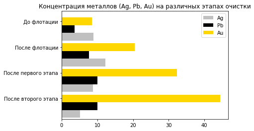

```python
df = pd.DataFrame(dict(graph=['После второго этапа', 'После первого этапа', 'После флотации', 'До флотации'],
                       ag=[desc4.values[0], desc3.values[0], desc2.values[0], desc1.values[0]],
                       pb=[desc4.values[1], desc3.values[1], desc2.values[1], desc1.values[1]],
                       au=[desc4.values[2], desc3.values[2], desc2.values[2], desc1.values[2]]))

ind = np.arange(len(df))
width = 0.3

fig, ax = plt.subplots()
ax.barh(ind, df.ag, width, color='silver', label='Ag')
ax.barh(ind + width, df.pb, width, color='black', label='Pb')
ax.barh(ind + width + width, df.au, width, color='gold', label='Au')

ax.set(yticks=ind + width + width, yticklabels=df.graph, ylim=[3*width-1.1, len(df)])
ax.legend()

plt.title('Концентрация металлов (Ag, Pb, Au) на различных этапах очистки')
plt.show()
```

*Вывод:*

Как я понимаю, output после второй чистки и есть final_output.

Собственно, все манипуляции технологического процесса направленны на повышение концентрации золота на выходе.

- На всех этапах очистки концентрация золота увеличивается (почти в 5 раз, по сравнению с изначальной концентрацией)
- Концентрация свинца увеличивается достаточно плавно и почти не изменяется в массовом содержании после первого этапа очистки
- Концентрация серебра увеличивается после флотации и далее уменьшается во время этапов очистки

### Сравните распределения размеров гранул сырья на обучающей и тестовой выборках. Если распределения сильно отличаются друг от друга, оценка модели будет неправильной.

*rougher.input.feed_size*

```python
rougher_train_sample = gold_recovery_train['rougher.input.feed_size'].sample(1000)
rougher_test_sample = gold_recovery_test['rougher.input.feed_size'].sample(1000)
```

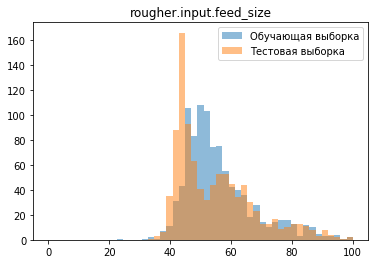

```python
bins = np.linspace(0, 100, 50)

plt.title('rougher.input.feed_size')
plt.hist(rougher_train_sample, bins, alpha=0.5, label='Обучающая выборка')
plt.hist(rougher_test_sample, bins, alpha=0.5, label='Тестовая выборка')
plt.legend(loc='upper right')
plt.show()
```

*primary_cleaner.input.feed_size*

```python
primary_cleaner_train_sample = gold_recovery_train['primary_cleaner.input.feed_size'].sample(1000)
primary_cleaner_test_sample = gold_recovery_test['primary_cleaner.input.feed_size'].sample(1000)
```

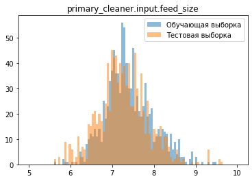

```python
bins = np.linspace(5, 10, 100)

plt.title('primary_cleaner.input.feed_size')
plt.hist(primary_cleaner_train_sample, bins, alpha=0.5, label='Обучающая выборка')
plt.hist(primary_cleaner_test_sample, bins, alpha=0.5, label='Тестовая выборка')
plt.legend(loc='upper right')
plt.show()
```

*Вывод:*

В случае с primary_cleaner.input.feed_size распределение значений идет довольно ровно, а что касается rougher.input.feed_size присутствует сдвиг.

Понятное дело, что частицы разного размера и после флотации их размер усредняется, но, как я понимаю, сдвиг между трейном и тестом достаточно частое явление и, если он небольной, то с этим приходится мириться...

### Исследуйте суммарную концентрацию всех веществ на разных стадиях: в сырье, в черновом и финальном концентратах.

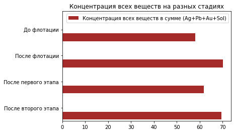

```python
df = pd.DataFrame(dict(graph=['После второго этапа', 'После первого этапа', 'После флотации', 'До флотации'],
                       substances=[desc4.values[0]+desc4.values[1]+desc4.values[2]+desc4.values[3],
                                  desc3.values[0]+desc3.values[1]+desc3.values[2]+desc3.values[3],
                                  desc2.values[0]+desc2.values[1]+desc2.values[2]+desc2.values[3],
                                  desc1.values[0]+desc1.values[1]+desc1.values[2]+desc1.values[3]]))

ind = np.arange(len(df))
width = 0.3

fig, ax = plt.subplots()
ax.barh(ind, df.substances, width, color='brown', label='Концентрация всех веществ в сумме (Ag+Pb+Au+Sol)')

ax.set(yticks=ind + width, yticklabels=df.graph, ylim=[3*width-1.1, len(df)])
ax.legend()

plt.title('Концентрация всех веществ на разных стадиях')
plt.show()
```

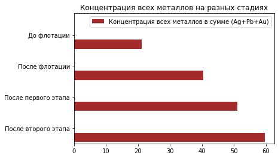

```python
df = pd.DataFrame(dict(graph=['После второго этапа', 'После первого этапа', 'После флотации', 'До флотации'],
                       substances=[desc4.values[0]+desc4.values[1]+desc4.values[2],
                                  desc3.values[0]+desc3.values[1]+desc3.values[2],
                                  desc2.values[0]+desc2.values[1]+desc2.values[2],
                                  desc1.values[0]+desc1.values[1]+desc1.values[2]]))

ind = np.arange(len(df))
width = 0.3

fig, ax = plt.subplots()
ax.barh(ind, df.substances, width, color='brown', label='Концентрация всех металлов в сумме (Ag+Pb+Au)')

ax.set(yticks=ind + width, yticklabels=df.graph, ylim=[3*width-1.1, len(df)])
ax.legend()

plt.title('Концентрация всех металлов на разных стадиях')
plt.show()
```

*Вывод:*

По закону сохранения массы, концентрация ВСЕХ веществ колеблется примерно на одном и том же уровне, но что-то переходит в tail, что-то остается. А вот содержание в смеси целевых продуктов - металлов, а конкретно, золота, - растет!

```python
rougherinput_conc
```

|  | rougher.input.feed_ag | rougher.input.feed_pb | rougher.input.feed_au | rougher.input.feed_sol | sum |
| --- | --- | --- | --- | --- | --- |
| 0 | 6.100378 | 2.284912 | 6.486150 | 36.808594 | 51.680034 |
| 1 | 6.161113 | 2.266033 | 6.478583 | 35.753385 | 50.659114 |
| 2 | 6.116455 | 2.159622 | 6.362222 | 35.971630 | 50.609929 |
| 3 | 6.043309 | 2.037807 | 6.118189 | 36.862241 | 51.061546 |
| 4 | 6.060915 | 1.786875 | 5.663707 | 34.347666 | 47.859163 |
| ... | ... | ... | ... | ... | ... |
| 19434 | 6.091855 | 4.617558 | 5.335862 | 37.369774 | 53.415050 |
| 19435 | 6.121323 | 4.144989 | 4.838619 | 38.591551 | 53.696482 |
| 19436 | 5.970515 | 4.020002 | 4.525061 | 40.074026 | 54.589604 |
| 19437 | 6.048130 | 3.902537 | 4.362781 | 39.713906 | 54.027355 |
| 19438 | 6.158718 | 3.875727 | 4.365491 | 39.135119 | 53.535054 |

16089 rows × 5 columns

```python
rougheroutput_conc
```

|  | rougher.output.concentrate_ag | rougher.output.concentrate_pb | rougher.output.concentrate_au | rougher.output.concentrate_sol | sum |
| --- | --- | --- | --- | --- | --- |
| 0 | 11.500771 | 7.101074 | 19.793808 | 28.029297 | 66.424950 |
| 1 | 11.615865 | 7.278807 | 20.050975 | 28.067063 | 67.012710 |
| 2 | 11.695753 | 7.216833 | 19.737170 | 27.454037 | 66.103793 |
| 3 | 11.915047 | 7.175616 | 19.320810 | 27.341277 | 65.752751 |
| 4 | 12.411054 | 7.240205 | 19.216101 | 27.041023 | 65.908382 |
| ... | ... | ... | ... | ... | ... |
| 19434 | 11.124896 | 10.984003 | 18.603550 | 30.068876 | 70.781325 |
| 19435 | 11.425983 | 10.888213 | 18.441436 | 29.783972 | 70.539603 |
| 19436 | 8.523497 | 8.955135 | 15.111231 | 22.786467 | 55.376330 |
| 19437 | 11.658799 | 10.655377 | 17.834772 | 29.052742 | 69.201689 |
| 19438 | 11.959486 | 10.702148 | 17.804134 | 29.078235 | 69.544003 |

15788 rows × 5 columns

```python
primary_cleaner_conc
```

|  | primary_cleaner.output.concentrate_ag | primary_cleaner.output.concentrate_pb | primary_cleaner.output.concentrate_au | primary_cleaner.output.concentrate_sol | sum |
| --- | --- | --- | --- | --- | --- |
| 0 | 8.547551 | 10.389648 | 34.174427 | 19.529297 | 72.640924 |
| 1 | 8.558743 | 10.497069 | 34.118526 | 19.369147 | 72.543485 |
| 2 | 8.603505 | 10.354494 | 33.969464 | 19.167579 | 72.095042 |
| 3 | 7.221879 | 8.496563 | 28.260743 | 15.978538 | 59.957723 |
| 4 | 9.089428 | 9.986786 | 33.044932 | 19.199864 | 71.321010 |
| ... | ... | ... | ... | ... | ... |
| 19434 | 6.559174 | 12.445966 | 32.940215 | 7.056338 | 59.001692 |
| 19435 | 6.612376 | 12.623947 | 32.925325 | 7.542264 | 59.703912 |
| 19436 | 7.128896 | 12.633558 | 31.856742 | 7.941900 | 59.561096 |
| 19437 | 7.490444 | 12.012378 | 30.770892 | 6.942972 | 57.216686 |
| 19438 | 7.537584 | 11.650285 | 30.356618 | 6.203553 | 55.748041 |

15957 rows × 5 columns

```python
final_conc
```

|  | final.output.concentrate_ag | final.output.concentrate_pb | final.output.concentrate_au | final.output.concentrate_sol | sum |
| --- | --- | --- | --- | --- | --- |
| 0 | 6.055403 | 9.889648 | 42.192020 | 5.507324 | 63.644396 |
| 1 | 6.029369 | 9.968944 | 42.701629 | 5.257781 | 63.957723 |
| 2 | 6.055926 | 10.213995 | 42.657501 | 5.383759 | 64.311180 |
| 3 | 6.047977 | 9.977019 | 42.689819 | 4.858634 | 63.573449 |
| 4 | 6.148599 | 10.142511 | 42.774141 | 4.939416 | 64.004667 |
| ... | ... | ... | ... | ... | ... |
| 19434 | 3.224920 | 11.356233 | 46.713954 | 6.803482 | 68.098589 |
| 19435 | 3.195978 | 11.349355 | 46.866780 | 6.862249 | 68.274362 |
| 19436 | 3.109998 | 11.434366 | 46.795691 | 6.886013 | 68.226068 |
| 19437 | 3.367241 | 11.625587 | 46.408188 | 6.799433 | 68.200449 |
| 19438 | 3.598375 | 11.737832 | 46.299438 | 6.717509 | 68.353154 |

16053 rows × 5 columns

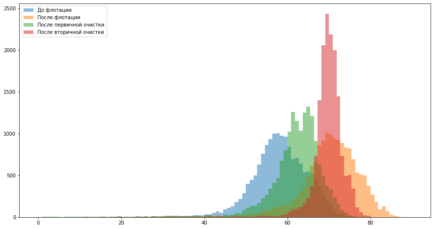

```python
bins = np.linspace(0, 90, 100)

# plt.title('Распределение')
plt.figure(figsize=(15,8))

plt.hist(rougherinput_conc['sum'], bins, alpha=0.5, label='До флотации')
plt.hist(rougheroutput_conc['sum'], bins, alpha=0.5, label='После флотации')
plt.hist(primary_cleaner_conc['sum'], bins, alpha=0.5, label='После первичной очистки')
plt.hist(final_conc['sum'], bins, alpha=0.5, label='После вторичной очистки')
plt.legend(loc='upper left')
plt.show()
```

[figure not shown]

```python
gold_recovery_train.loc[(gold_recovery_train[gold_recovery_train.columns] == 0).any(axis=1)]
```

|  | date | final.output.concentrate_ag | final.output.concentrate_pb | final.output.concentrate_sol | final.output.concentrate_au | final.output.recovery | final.output.tail_ag | final.output.tail_pb | final.output.tail_sol | final.output.tail_au | primary_cleaner.input.sulfate | primary_cleaner.input.depressant | primary_cleaner.input.feed_size | primary_cleaner.input.xanthate | primary_cleaner.output.concentrate_ag | primary_cleaner.output.concentrate_pb | primary_cleaner.output.concentrate_sol | primary_cleaner.output.concentrate_au | primary_cleaner.output.tail_ag | primary_cleaner.output.tail_pb | primary_cleaner.output.tail_sol | primary_cleaner.output.tail_au | primary_cleaner.state.floatbank8_a_air | primary_cleaner.state.floatbank8_a_level | primary_cleaner.state.floatbank8_b_air | primary_cleaner.state.floatbank8_b_level | primary_cleaner.state.floatbank8_c_air | primary_cleaner.state.floatbank8_c_level | primary_cleaner.state.floatbank8_d_air | … |
| --- | --- | --- | --- | --- | --- | --- | --- | --- | --- | --- | --- | --- | --- | --- | --- | --- | --- | --- | --- | --- | --- | --- | --- | --- | --- | --- | --- | --- | --- | --- |
| 19 | 2016-01-15 19:00:00 | 5.658943 | 10.436002 | 5.942418 | 42.509402 | 70.348300 | 10.232392 | 1.174845 | 19.498566 | 2.272460 | 149.998260 | 12.509947 | 7.25 | 0.997030 | 0.000000 | 0.000000 | 0.000000 | 0.000000 | 14.915949 | 2.702527 | 7.784534 | 2.013487 | 1599.617983 | -499.527131 | 1599.389604 | -499.554869 | 1600.441370 | -500.503609 | 1601.900702 | … |
| 22 | 2016-01-15 22:00:00 | 6.118749 | 10.483007 | 6.546983 | 41.406172 | 69.823900 | 10.322077 | 1.270956 | 19.384247 | 2.245145 | 158.353434 | 14.020791 | 7.25 | 0.997999 | 0.000000 | 0.000000 | 0.000000 | 0.000000 | 13.874346 | 2.440897 | 8.529620 | 1.964468 | 1596.351031 | -498.896997 | 1596.177717 | -500.402418 | 1598.280618 | -498.946313 | 1600.472486 | … |
| 30 | 2016-01-16 06:00:00 | 5.322681 | 9.577672 | 4.805490 | 44.059908 | 69.193840 | 10.334312 | 1.406355 | 19.923319 | 2.239310 | 145.952867 | 13.947704 | 7.25 | 0.991678 | 0.000000 | 0.000000 | 0.000000 | 0.000000 | 14.613684 | 2.893445 | 8.537165 | 1.982306 | 1599.096777 | -498.630270 | 1599.484314 | -499.255872 | 1598.366222 | -499.198198 | 1602.317332 | … |
| 45 | 2016-01-16 21:00:00 | 4.566664 | 10.406178 | 4.588698 | 46.614456 | 68.403877 | 10.705777 | 1.509070 | 17.875134 | 2.509776 | 131.251366 | 13.969457 | 7.25 | 1.203034 | 8.513177 | 9.724797 | 19.120964 | 37.633572 | 16.455383 | 3.366501 | 6.864404 | 3.434734 | 1601.674776 | -500.285160 | 1600.151967 | -499.633542 | 1599.542959 | -499.495721 | 1599.342687 | … |
| 46 | 2016-01-16 22:00:00 | 4.577832 | 10.691605 | 5.274175 | 46.250638 | 70.675633 | 10.728531 | 1.641216 | 18.349339 | 2.540843 | 141.184039 | 13.978607 | 7.25 | 1.248254 | 8.466262 | 9.780929 | 19.220963 | 37.718947 | 15.517931 | 3.076929 | 7.321526 | 3.102171 | 1604.852903 | -500.922517 | 1603.005456 | -499.631837 | 1599.307763 | -501.200791 | 1599.437018 | … |
| ... | ... | ... | ... | ... | ... | ... | ... | ... | ... | ... | ... | ... | ... | ... | ... | ... | ... | ... | ... | ... | ... | ... | ... | ... | ... | ... | ... | ... | ... | … |
| 14144 | 2018-08-18 06:59:59 | 3.224920 | 11.356233 | 6.803482 | 46.713954 | 73.755150 | 8.769645 | 3.141541 | 10.403181 | 1.529220 | 123.381787 | 8.028927 | 6.50 | 1.304232 | 6.559174 | 12.445966 | 7.056338 | 32.940215 | 22.854592 | 6.531541 | 3.934320 | 2.314352 | 1648.421193 | -400.382169 | 1648.742005 | -400.359661 | 1648.578230 | -399.363624 | 1648.833984 | … |
| 14145 | 2018-08-18 07:59:59 | 3.195978 | 11.349355 | 6.862249 | 46.866780 | 69.049291 | 8.897321 | 3.130493 | 10.549470 | 1.612542 | 120.878188 | 7.962636 | 6.50 | 1.302419 | 6.612376 | 12.623947 | 7.542264 | 32.925325 | 23.002490 | 6.629725 | 4.089124 | 2.462890 | 1649.820162 | -399.930973 | 1649.357538 | -399.721222 | 1648.656192 | -401.195834 | 1649.725133 | … |
| 14146 | 2018-08-18 08:59:59 | 3.109998 | 11.434366 | 6.886013 | 46.795691 | 67.002189 | 8.529606 | 2.911418 | 11.115147 | 1.596616 | 105.666118 | 7.955111 | 6.50 | 1.315926 | 7.128896 | 12.633558 | 7.941900 | 31.856742 | 22.298149 | 6.278250 | 4.457457 | 2.612231 | 1649.166761 | -399.888631 | 1649.196904 | -399.677571 | 1647.896999 | -399.988275 | 1649.772714 | … |
| 14147 | 2018-08-18 09:59:59 | 3.367241 | 11.625587 | 6.799433 | 46.408188 | 65.523246 | 8.777171 | 2.819214 | 10.463847 | 1.602879 | 98.880538 | 7.984164 | 6.50 | 1.241969 | 7.490444 | 12.012378 | 6.942972 | 30.770892 | 22.714656 | 6.253145 | 3.557121 | 2.800648 | 1646.547763 | -398.977083 | 1648.212240 | -400.383265 | 1648.917387 | -399.521344 | 1651.498591 | … |
| 14148 | 2018-08-18 10:59:59 | 3.598375 | 11.737832 | 6.717509 | 46.299438 | 70.281454 | 8.406690 | 2.517518 | 10.652193 | 1.389434 | 95.248427 | 8.078957 | 6.50 | 1.283045 | 7.537584 | 11.650285 | 6.203553 | 30.356618 | 22.735927 | 6.084287 | 3.026699 | 2.708046 | 1648.759906 | -399.862053 | 1650.135395 | -399.957321 | 1648.831890 | -400.586116 | 1649.464582 | … |

732 rows × 87 columns

```python
gold_recovery_train = gold_recovery_train.loc[(gold_recovery_train[gold_recovery_train.columns] != 0).any(axis=1)]
```

an_Indexes = gold_recovery_train[(gold_recovery_train['base.all.materials'] == 0) | (gold_recovery_train['rougher.all.materials'] == 0) | (gold_recovery_train['primary.all.materials'] == 0) | (gold_recovery_train['final.all.materials'] == 0)] gold_recovery_train.drop(an_Indexes.index, inplace=True)

## Модель

### Напишите функцию для вычисления итоговой sMAPE.

Формулы метрик качества:

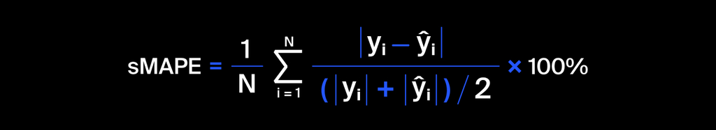

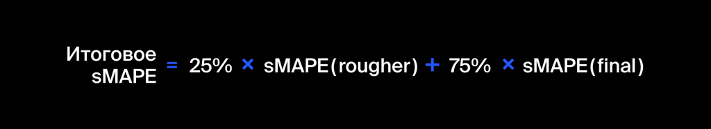

```python
def total_sMAPE_calculation(target, predictions):
    target1 = target.to_numpy()
    predictions1 = predictions
    target_rougher = list()
    predictions_rougher = list()
    target_final = list()
    predictions_final = list()

    summa_rougher = 0
    summa_final = 0

    for i in range(len(target1)):
        target_rougher.append(target1[i][0])
        target_final.append(target1[i][1])
        predictions_rougher.append(predictions1[i][0])
        predictions_final.append(predictions1[i][1])

    y_pred = np.array(predictions_rougher)
#     print(y_pred)
    y_true = np.array(target_rougher)
#     print(y_true)
    sMAPE_rougher = 2.0 * np.nanmean(np.abs(y_pred - y_true) / (np.abs(y_pred) + np.abs(y_true))) * 100
#     print(sMAPE_rougher)

    y_pred = np.array(predictions_final)
#     print(y_pred)
    y_true = np.array(target_final)
#     print(target_final)
    sMAPE_final = 2.0 * np.nanmean(np.abs(y_pred - y_true) / (np.abs(y_pred) + np.abs(y_true))) * 100
#     print(sMAPE_final)

    total_sMAPE = (0.25 * sMAPE_rougher) + (0.75 * sMAPE_final)
    return total_sMAPE
```

### Обучите разные модели и оцените их качество кросс-валидацией. Выберите лучшую модель и проверьте её на тестовой выборке. Опишите выводы.

Нужно спрогнозировать сразу две величины:

- эффективность обогащения чернового концентрата rougher.output.recovery;
- эффективность обогащения финального концентрата final.output.recovery.

```python
nedostupnie
```

```
['final.output.concentrate_ag',
 'final.output.concentrate_pb',
 'final.output.concentrate_sol',
 'final.output.concentrate_au',
 'final.output.recovery',
 'final.output.tail_ag',
 'final.output.tail_pb',
 'final.output.tail_sol',
 'final.output.tail_au',
 'primary_cleaner.output.concentrate_ag',
 'primary_cleaner.output.concentrate_pb',
 'primary_cleaner.output.concentrate_sol',
 'primary_cleaner.output.concentrate_au',
 'primary_cleaner.output.tail_ag',
 'primary_cleaner.output.tail_pb',
 'primary_cleaner.output.tail_sol',
 'primary_cleaner.output.tail_au',
 'rougher.calculation.sulfate_to_au_concentrate',
 'rougher.calculation.floatbank10_sulfate_to_au_feed',
 'rougher.calculation.floatbank11_sulfate_to_au_feed',
 'rougher.calculation.au_pb_ratio',
 'rougher.output.concentrate_ag',
 'rougher.output.concentrate_pb',
 'rougher.output.concentrate_sol',
 'rougher.output.concentrate_au',
 'rougher.output.recovery',
 'rougher.output.tail_ag',
 'rougher.output.tail_pb',
 'rougher.output.tail_sol',
 'rougher.output.tail_au',
 'secondary_cleaner.output.tail_ag',
 'secondary_cleaner.output.tail_pb',
 'secondary_cleaner.output.tail_sol',
 'secondary_cleaner.output.tail_au']
```

```python
df = gold_recovery_train
target_train = df[['rougher.output.recovery', 'final.output.recovery']]
df = df.drop(nedostupnie, axis = 1)
features_train = df.drop(['date'], axis = 1)
```

```python
# features_train, features_valid, target_train, target_valid = train_test_split(features, target, test_size = 0.25, random_state = 12345)
```

```python
print('Размеры тренировочной выборки:')
print(features_train.shape)
print(target_train.shape)
```

```
Размеры тренировочной выборки:
(11017, 52)
(11017, 2)
```

```python
print('Скаляризация - уравновешивание признаков...')

scaler = StandardScaler()

features_train = scaler.fit_transform(features_train)
```

```
Скаляризация - уравновешивание признаков...
```

```python
sMAPE_scorer = make_scorer(total_sMAPE_calculation, greater_is_better=False)
```

*Модель LinearRegression*

```python
model1 = LinearRegression()
model1.fit(features_train, target_train.sort_index())
predictions_train = model1.predict(features_train)
```

```python
print('Средняя оценка качества модели (итоговый sMAPE):')
print(cross_val_score(model1, features_train, target_train.sort_index(), scoring=sMAPE_scorer, cv=5).sum() / 5)
```

```
Средняя оценка качества модели (итоговый sMAPE):
-10.290896728293244
```

*Модель DecisionTreeRegressor*

```python
model2 = DecisionTreeRegressor(random_state = 12345)
model2.fit(features_train, target_train.sort_index())
predictions_train = model2.predict(features_train)
```

```python
print('Средняя оценка качества модели (итоговый sMAPE):')
print(cross_val_score(model2, features_train, target_train.sort_index(), scoring=sMAPE_scorer, cv=5).sum() / 5)
```

```
Средняя оценка качества модели (итоговый sMAPE):
-17.90605373619217
```

*Модель RandomForestRegressor*

```python
parametrs = {'n_estimators': range (1, 5, 2),
              'max_depth': range (1, 7, 2),
              'min_samples_leaf': range (1, 4),
              'min_samples_split': range (2,6,2)}
```

```python
model3 = RandomForestRegressor(random_state=12345)
model3.fit(features_train, target_train.sort_index())
predictions_train = model3.predict(features_train)

grid = GridSearchCV(model3, parametrs, cv=5)
grid.fit(features_train, target_train.sort_index())
grid.best_params_
```

```
{'max_depth': 3,
 'min_samples_leaf': 1,
 'min_samples_split': 2,
 'n_estimators': 3}
```

👍

```python
model4 = RandomForestRegressor(random_state=12345, max_depth = 1, min_samples_leaf = 1, min_samples_split = 2, n_estimators = 3)
model4.fit(features_train, target_train.sort_index())
predictions_train = model4.predict(features_train)
```

```python
print('Средняя оценка качества модели (итоговый sMAPE):')
print(cross_val_score(model4, features_train, target_train.sort_index(), scoring=sMAPE_scorer, cv=5).sum() / 5)
```

```
Средняя оценка качества модели (итоговый sMAPE):
-9.540062894780077
```

*Выбор лучшей модели и ее проверка*

Я явно сделал что-то не то, так как все модели вышли фигово...

Жду Ваших замечаний по поводу проекта, исправлений, как я понимаю, будет много))

```python
from sklearn.dummy import DummyRegressor
```

Значение для обучающей выборки, как я понимаю, здесь мы получаем значение total_sMAPE, которое мы получим, если заменима все значения медианами

```python
model_check = DummyRegressor(strategy = 'median')
model_check.fit(features_train, target_train)
print(cross_val_score(model_check, features_train, target_train.sort_index(), scoring=sMAPE_scorer, cv=5).sum() / 5)
```

```
-10.259372061463598
```

```python
def total_sMAPE_calculation(target, predictions):
    target1 = target
    predictions1 = predictions
    target_rougher = list()
    predictions_rougher = list()
    target_final = list()
    predictions_final = list()

    summa_rougher = 0
    summa_final = 0

    for i in range(len(target1)):
        target_rougher.append(target1[i][0])
        target_final.append(target1[i][1])
        predictions_rougher.append(predictions1[i][0])
        predictions_final.append(predictions1[i][1])

    y_pred = np.array(predictions_rougher)
#     print(y_pred)
    y_true = np.array(target_rougher)
#     print(y_true)
    sMAPE_rougher = 2.0 * np.nanmean(np.abs(y_pred - y_true) / (np.abs(y_pred) + np.abs(y_true))) * 100
#     print(sMAPE_rougher)

    y_pred = np.array(predictions_final)
#     print(y_pred)
    y_true = np.array(target_final)
#     print(target_final)
    sMAPE_final = 2.0 * np.nanmean(np.abs(y_pred - y_true) / (np.abs(y_pred) + np.abs(y_true))) * 100
#     print(sMAPE_final)

    total_sMAPE = (0.25 * sMAPE_rougher) + (0.75 * sMAPE_final)
    return total_sMAPE
```

```python
sMAPE_scorer = make_scorer(total_sMAPE_calculation, greater_is_better=False)
```

```python
features_test = gold_recovery_test.drop(['date'], axis=1)
predictions_test = model1.predict(features_test)
print(cross_val_score(model_check, features_test, predictions_test, scoring=sMAPE_scorer, cv=5).sum() / 5)
```

```
-52.90100284123088
```

targets_to_join = data_full[['date', 'final.output.recovery', 'rougher.output.recovery']].copy() data_test = data_test.join(targets_to_join.set_index('date'), on='date')

```python
# targets_to_join = gold_recovery_full[['date', 'final.output.recovery', 'rougher.output.recovery']].copy()
# data_test = gold_recovery_test.join(targets_to_join.set_index('date'), on='date')
```

```python
# data_test.head(3)
```

В полученном data_test есть NaNы по индексам, их необходимо удалить

```python
targets_to_join = gold_recovery_full[['date', 'final.output.recovery', 'rougher.output.recovery']].copy()
data_test = gold_recovery_test.merge(targets_to_join, on='date')
```

```python
data_test
indexes = data_test.loc[(data_test[data_test.columns].isna() == True).any(axis=1)]
# data_test.drop(data_test.index[list(indexes.index)], inplace=True)
```

```python
targets_test = data_test[['final.output.recovery', 'rougher.output.recovery']]
features_t_test = data_test.drop(['date', 'final.output.recovery', 'rougher.output.recovery'], axis=1)
```

```python
targets_test_dropped = targets_test.drop(targets_test.index[list(indexes.index)], axis = 0)
features_t_test_dropped = features_t_test.drop(features_t_test.index[list(indexes.index)], axis = 0)
```

```python
targets_test_dropped
```

|  | final.output.recovery | rougher.output.recovery |
| --- | --- | --- |
| 0 | 70.273583 | 89.993421 |
| 1 | 68.910432 | 88.089657 |
| 2 | 68.143213 | 88.412756 |
| 3 | 67.776393 | 87.360133 |
| 4 | 61.467078 | 83.236367 |
| ... | ... | ... |
| 5072 | 68.919891 | 95.172585 |
| 5073 | 68.440582 | 94.575036 |
| 5074 | 67.092759 | 93.018138 |
| 5075 | 68.061186 | 92.599042 |
| 5076 | 71.699976 | 91.177695 |

5077 rows × 2 columns

*Сравнение total_sMAPE*

Симметричная процентная ошибка, если наша модель будет подставлять вместо predictов медианы.

```python
print(cross_val_score(model_check, features_t_test_dropped, targets_test_dropped.to_numpy(), scoring=sMAPE_scorer, cv=5).sum() / 5)
```

```
-7.949788895116598
```

Симметричная процентная ошибка при использовании модели линейной регрессии

```python
print(cross_val_score(model1, features_t_test_dropped, targets_test_dropped.to_numpy(), scoring=sMAPE_scorer, cv=5).sum() / 5)
```

```
-11.603061118970277
```

*Вывод*

Выходит, согласно значениям total_sMAPE выбранная модель линейной регрессии работает хуже, чем подставление медианных значений на место predictов.

https://askdev.ru/q/v-chem-raznica-mezhdu-join-i-merge-v-pand-27122/

## Чек-лист готовности проекта

- [x] Jupyter Notebook открыт
- [ ] Весь код выполняется без ошибок
- [ ] Ячейки с кодом расположены в порядке выполнения
- [ ] Выполнен шаг 1: данные подготовлены
  - [ ] Проверена формула вычисления эффективности обогащения
  - [ ] Проанализированы признаки, недоступные в тестовой выборке
  - [ ] Проведена предобработка данных
- [ ] Выполнен шаг 2: данные проанализированы
  - [ ] Исследовано изменение концентрации элементов на каждом этапе
  - [ ] Проанализированы распределения размеров гранул на обучающей и тестовой выборках
  - [ ] Исследованы суммарные концентрации
- [ ] Выполнен шаг 3: построена модель прогнозирования
  - [ ] Написана функция для вычисления итогового *sMAPE*
  - [ ] Обучено и проверено несколько моделей
  - [ ] Выбрана лучшая модель, её качество проверено на тестовой выборке